# Unveiling the factors significantly associated with coronary heart disease diagnosis?

Team Confusion Matrix Mafia: Dhanush Mathivanan, Heng Jui Chu, Nikhilesh Dhavale, Aditya Karande

2025-12-09

# Abstract

This study examines lifestyle and health factors linked to coronary heart disease (CHD) in people under 70 using a large survey dataset. After data cleaning and handling missing values, we use t-tests and chi-square tests to analyze age, sex, BMI, smoking, diabetes, exercise, and health status. Results show higher age, BMI, diabetes, and smoking increase CHD risk, while exercise and better health lower it. These findings highlight the importance of healthy behaviors for CHD prevention.

# Motivation for Topic Selection

Coronary heart disease is a major global health issue. We chose this topic to better understand risk factors for CHD and support prevention. Identifying modifiable risks and lifestyle choices can help reduce the burden of heart disease.

# Prior Research and Analysis

Prior studies, including the [Framingham Heart Study](https://www.framinghamheartstudy.org/) and [INTERHEART](https://www.phri.ca/research/interheart/), have shown that age, sex, diabetes, smoking, obesity, inactivity, and poor health are key CHD risk factors. The BRFSS dataset is widely used to track these risks and evaluate interventions. Our study uses recent BRFSS 2024 data and statistical methods to clarify the importance of these factors today.

# Dataset Description

We used data from the 2024 BRFSS, a national CDC survey of US adults. The dataset covers health behaviors, conditions, and demographics, with over 300 variables. More details: [CDC BRFSS Annual Data 2024](https://www.cdc.gov/brfss/annual_data/annual_2024.html).

# Variables Used for Analysis

The following variables were selected based on clinical relevance and prior research indicating their association with coronary heart disease (CHD):

- **Age**: Age group of the respondent
- **Sex**: Biological sex
- **Diabetes_Status**: Diabetes diagnosis status
- **Smoking_Status**: Lifetime smoking status
- **BMI_Category_Alt**: BMI category (Underweight, Normal, Overweight, Obese)
- **Exercise_Past_30_Days**: Physical activity in the past 30 days
- **Coronary_Heart_Disease**: CHD diagnosis status (outcome variable)
- **Heart_Attack_History**: History of heart attack
- **General_Health_Status**: Self-reported general health status
- **BMI_Value**: Calculated BMI value

# Variable Selection Criteria

These variables are established CHD risk factors or predictors, supported by research and guidelines. We include demographic, behavioral, metabolic, and health measures for a comprehensive analysis. Variables with high missingness were excluded for reliability.

# Data Loading & Preparation

```r
# Load necessary libraries
library(kableExtra)
library(knitr)

Heart_data <- data.frame(read.csv("BRFSS_2024_Readable_Columns.csv"))

# Variable transformation
Heart_data$Age_Group_5yr <- factor(
  Heart_data$Age_Group_5yr, levels = 1:13,
  labels = c("18-24", "25-29", "30-34", "35-39", "40-44", "45-49", "50-54", "55-59", "60-64", "65-69", "70-74", "75-79", "80+")
)
Heart_data$Sex <- factor(Heart_data$Sex, levels = c(1, 2), labels = c("Male", "Female"))
Heart_data$Diabetes_Status <- factor(Heart_data$Diabetes_Status, levels = c(1, 2, 3, 4), labels = c("Yes", "Yes/borderline", "Yes/pregnancy only", "No"))
Heart_data$Smoking_Status <- factor(Heart_data$Smoked_100_Cigarettes_Lifetime, levels = c(1, 2), labels = c("Yes", "No"))
Heart_data$BMI_Category_Alt <- factor(Heart_data$BMI_Category_Alt, levels = c(1, 2, 3, 4), labels = c("Underweight", "Normal Weight", "Overweight", "Obese"))
Heart_data$Exercise_Past_30_Days <- factor(Heart_data$Exercise_Past_30_Days, levels = c(1, 2), labels = c("Yes", "No"))
# Heart_data$CVD_Stroke_History <- factor(Heart_data$CVD_Stroke_History, levels = c(1, 2), labels = c("Yes", "No"))
Heart_data$Coronary_Heart_Disease <- factor(Heart_data$Coronary_Heart_Disease, levels = c(1, 2), labels = c("Yes", "No"))
Heart_data$Heart_Attack_History <- factor(Heart_data$Heart_Attack_History, levels = c(1, 2), labels = c("Yes", "No"))
Heart_data$General_Health_Status <- factor(Heart_data$General_Health_Status, levels = c(1, 2, 3, 4, 5), labels = c("Excellent", "Very Good", "Good", "Fair", "Poor"))
Heart_data$BMI_Value <- Heart_data$BMI_Category / 100

# Add state_code
Heart_data$State_Code <- factor(Heart_data$State_Code)

names(Heart_data)[names(Heart_data) == "Age_Group_5yr"] <- "Age"

# Select only the 14 key variables
selected_vars <- c(
  "Age", "Sex", "Diabetes_Status", "Smoking_Status", "BMI_Category_Alt",
  "Exercise_Past_30_Days", "Coronary_Heart_Disease",
  "Heart_Attack_History", "General_Health_Status", "BMI_Value", "State_Code"
)
Heart_data <- Heart_data[, selected_vars]

# Display first few rows of the dataset in a styled box
kable(head(Heart_data[, 1:6]), caption = "Initial Dataset Preview with few variables", align = 'c', format = "html") %>%
  kable_styling(bootstrap_options = c("striped", "bordered", "hover"), full_width = FALSE, position = "left")
```

Initial Dataset Preview with few variables

| Age | Sex | Diabetes_Status | Smoking_Status | BMI_Category_Alt | Exercise_Past_30_Days |
| --- | --- | --- | --- | --- | --- |
| 75-79 | Female | Yes/pregnancy only | No | Normal Weight | Yes |
| 80+ | Male | Yes/pregnancy only | Yes | Overweight | Yes |
| 55-59 | Male | Yes/pregnancy only | Yes | Normal Weight | Yes |
| 80+ | Male | Yes/pregnancy only | No | Overweight | Yes |
| 45-49 | Male | Yes/pregnancy only | No | Normal Weight | No |
| 50-54 | Male | Yes | No | Obese | Yes |

# Missing Value Analysis

```r
missing_analysis <- data.frame(
  Variable = names(Heart_data),
  Missing_Count = sapply(Heart_data, function(x) sum(is.na(x))),
  Missing_Percent = sapply(Heart_data, function(x) round((sum(is.na(x)) / length(x)) * 100, 2))
)
missing_analysis <- missing_analysis[order(-missing_analysis$Missing_Percent), ]

kable(
  missing_analysis,
  caption = "Missing Value Summary for Selected Variables",
  align = 'c',
  format = "html"
) %>%
  kable_styling(
    bootstrap_options = c("striped", "bordered", "hover"),
    full_width = FALSE,
    position = "left"
  )
```

Missing Value Summary for Selected Variables

|  | Variable | Missing_Count | Missing_Percent |
| --- | --- | --- | --- |
| BMI_Category_Alt | BMI_Category_Alt | 43037 | 9.40 |
| BMI_Value | BMI_Value | 43037 | 9.40 |
| Smoking_Status | Smoking_Status | 31472 | 6.88 |
| Age | Age | 8310 | 1.82 |
| Coronary_Heart_Disease | Coronary_Heart_Disease | 4578 | 1.00 |
| Heart_Attack_History | Heart_Attack_History | 3115 | 0.68 |
| Exercise_Past_30_Days | Exercise_Past_30_Days | 1315 | 0.29 |
| General_Health_Status | General_Health_Status | 1310 | 0.29 |
| Diabetes_Status | Diabetes_Status | 1034 | 0.23 |
| Sex | Sex | 0 | 0.00 |
| State_Code | State_Code | 0 | 0.00 |

# Data Cleaning

## Missing Value Treatment (Imputation - Median for continuous variables)

```r
rows_initial <- nrow(Heart_data)
Heart_clean <- Heart_data

# Impute continuous variables with 5-20% missing using median
continuous_vars <- c("BMI_Value")
for(var in continuous_vars) {
  if(var %in% names(Heart_clean)) {
    missing_before <- sum(is.na(Heart_clean[[var]]))
    missing_pct <- mean(is.na(Heart_clean[[var]])) * 100
    if(missing_pct >= 5 && missing_pct <= 20) {
      var_median <- median(Heart_clean[[var]], na.rm = TRUE)
      Heart_clean[[var]][is.na(Heart_clean[[var]])] <- var_median
      cat(sprintf("Imputed %d missing values in %s with median (%.2f)\n", missing_before, var, var_median))
    }
  }
}
```

Imputed 43037 missing values in BMI_Value with median (27.44)

```r
# Impute missing BMI_Category_Alt based on BMI_Value
if("BMI_Category_Alt" %in% names(Heart_clean) && "BMI_Value" %in% names(Heart_clean)) {
  missing_idx <- which(is.na(Heart_clean$BMI_Category_Alt) & !is.na(Heart_clean$BMI_Value))
  if(length(missing_idx) > 0) {
    bmi_vals <- Heart_clean$BMI_Value[missing_idx]
    bmi_cat <- cut(bmi_vals,
                  breaks = c(-Inf, 18.5, 24.9, 29.9, Inf),
                  labels = c("Underweight", "Normal Weight", "Overweight", "Obese"),
                  right = TRUE)
    Heart_clean$BMI_Category_Alt[missing_idx] <- bmi_cat
    cat(sprintf("Imputed %d missing BMI_Category_Alt values based on BMI_Value\n", length(missing_idx)))
  }
}
```

Imputed 43037 missing BMI_Category_Alt values based on BMI_Value

## Outlier Removal and Invalid Data Handling

```r
# Remove invalid General Health Status responses
if("General_Health_Status" %in% names(Heart_clean)) {
  rows_before <- nrow(Heart_clean)
  valid_health <- Heart_clean$General_Health_Status %in% c("Excellent", "Very Good", "Good", "Fair", "Poor")
  Heart_clean <- Heart_clean[valid_health, ]
  cat(sprintf("Removed %d rows with invalid General Health Status responses\n", rows_before - nrow(Heart_clean)))
}
```

Removed 1310 rows with invalid General Health Status responses

```r
# Remove invalid Exercise_Past_30_Days responses
if ("Exercise_Past_30_Days" %in% names(Heart_clean)) {
  rows_before <- nrow(Heart_clean)
  valid_exercise <- Heart_clean$Exercise_Past_30_Days %in% c("Yes", "No")
  Heart_clean <- Heart_clean[valid_exercise, ]
  cat(sprintf("Removed %d rows with invalid Exercise_Past_30_Days responses\n", rows_before - nrow(Heart_clean)))
}
```

Removed 1242 rows with invalid Exercise_Past_30_Days responses

```r
# Remove Age groups above 69 years
if ("Age" %in% names(Heart_clean)) {
  rows_before <- nrow(Heart_clean)
  valid_age_groups <- c("18-24", "25-29", "30-34", "35-39", "40-44", "45-49", "50-54", "55-59", "60-64", "65-69")
  Heart_clean <- Heart_clean[Heart_clean$Age %in% valid_age_groups, ]
  cat(sprintf("Removed %d rows with Age above 69 years\n", rows_before - nrow(Heart_clean)))
}
```

Removed 130469 rows with Age above 69 years

```r
# Remove Age label above 69
Heart_clean$Age <- factor(Heart_clean$Age)

# Remove rows with missing critical variables
critical_vars <- c("Coronary_Heart_Disease", "General_Health_Status", "Sex", "Exercise_Past_30_Days", "Diabetes_Status", "Smoking_Status", "BMI_Value", "BMI_Category_Alt", "Age")
available_critical <- critical_vars[critical_vars %in% names(Heart_clean)]
rows_before <- nrow(Heart_clean)
Heart_clean <- Heart_clean[complete.cases(Heart_clean[available_critical]), ]
cat(sprintf("Removed %d rows with missing critical variables\n", rows_before - nrow(Heart_clean)))
```

Removed 23830 rows with missing critical variables

```r
# Outlier treatment for BMI_Value
if("BMI_Value" %in% names(Heart_clean)) {
  rows_before <- nrow(Heart_clean)
  bmi_outliers <- which(Heart_clean$BMI_Value < 10 | Heart_clean$BMI_Value > 70)
  if(length(bmi_outliers) > 0) {
    Heart_clean <- Heart_clean[-bmi_outliers, ]
    cat(sprintf("Removed %d rows with impossible BMI values (<10 or >70)\n", rows_before - nrow(Heart_clean)))
  }
}
```

Removed 209 rows with impossible BMI values (<10 or >70)

## Handling CHD Distribution Class Imbalance based on Geographic Location

```r
if("State_Code" %in% names(Heart_clean) && "Coronary_Heart_Disease" %in% names(Heart_clean)) {
  # For each Yes CHD case, randomly sample a No CHD case from the same State_Code
  chd_yes_cases <- Heart_clean %>% filter(Coronary_Heart_Disease == "Yes")
  chd_no_cases <- Heart_clean %>% filter(Coronary_Heart_Disease == "No")

  set.seed(123)  # For reproducibility
  # To prevent duplicates, keep track of used No-CHD indices
  used_no_indices <- c()
  sampled_no_cases_list <- vector("list", nrow(chd_yes_cases))
  for (i in seq_len(nrow(chd_yes_cases))) {
    state <- chd_yes_cases$State_Code[i]
    # Get available No-CHD cases for this state, excluding already used
    no_cases_state <- chd_no_cases %>% filter(State_Code == state)
    if (nrow(no_cases_state) > 0) {
      available <- setdiff(seq_len(nrow(no_cases_state)), used_no_indices)
      # Map to global indices
      global_indices <- which(chd_no_cases$State_Code == state)
      available_global <- setdiff(global_indices, used_no_indices)
      if (length(available_global) > 0) {
        pick <- sample(available_global, 1)
        used_no_indices <- c(used_no_indices, pick)
        sampled_no_cases_list[[i]] <- chd_no_cases[pick, ]
      } else {
        # If all state No-CHD cases used, sample from all unused No-CHD
        available_global <- setdiff(seq_len(nrow(chd_no_cases)), used_no_indices)
        if (length(available_global) > 0) {
          pick <- sample(available_global, 1)
          used_no_indices <- c(used_no_indices, pick)
          sampled_no_cases_list[[i]] <- chd_no_cases[pick, ]
        } else {
          stop("Not enough unique No-CHD cases to match all Yes-CHD cases.")
        }
      }
    } else {
      # If no No-CHD in state, sample from all unused No-CHD
      available_global <- setdiff(seq_len(nrow(chd_no_cases)), used_no_indices)
      if (length(available_global) > 0) {
        pick <- sample(available_global, 1)
        used_no_indices <- c(used_no_indices, pick)
        sampled_no_cases_list[[i]] <- chd_no_cases[pick, ]
      } else {
        stop("Not enough unique No-CHD cases to match all Yes-CHD cases.")
      }
    }
  }
  sampled_no_cases <- bind_rows(sampled_no_cases_list)
  Heart_clean_balanced <- bind_rows(chd_yes_cases, sampled_no_cases)
  cat(sprintf("\nTotal CHD Yes cases: %d\n", nrow(chd_yes_cases)))
  cat(sprintf("\nTotal CHD No cases sampled: %d\n", nrow(sampled_no_cases)))
  cat(sprintf("\nTotal balanced dataset size: %d (matched by State_Code without duplicates)\n", nrow(Heart_clean_balanced)))
  Heart_clean <- Heart_clean_balanced
  cat(sprintf("\nHeart_clean dataset updated with state-matched random sampling (no duplicates)\n"))
  cat(sprintf("\nPerfect 50/50 balance achieved: %d Yes cases, %d No cases\n",
              sum(Heart_clean$Coronary_Heart_Disease == "Yes"),
              sum(Heart_clean$Coronary_Heart_Disease == "No")))
}
```

Total CHD Yes cases: 10883

Total CHD No cases sampled: 10883

Total balanced dataset size: 21766 (matched by State_Code without duplicates)

Heart_clean dataset updated with state-matched random sampling (no duplicates)

Perfect 50/50 balance achieved: 10883 Yes cases, 10883 No cases

# Descriptive Statistics

```r
# Display first few rows of the dataset in a styled box
kable(head(Heart_clean[, 1:6]), caption = "Final Dataset Preview with few variables", align = 'c', format = "html") %>%
  kable_styling(bootstrap_options = c("striped", "bordered", "hover"), full_width = FALSE, position = "left")
```

Final Dataset Preview with few variables

| Age | Sex | Diabetes_Status | Smoking_Status | BMI_Category_Alt | Exercise_Past_30_Days |
| --- | --- | --- | --- | --- | --- |
| 65-69 | Female | Yes | No | Obese | No |
| 55-59 | Female | Yes | No | Obese | No |
| 65-69 | Female | Yes/pregnancy only | Yes | Obese | Yes |
| 55-59 | Female | Yes | No | Overweight | No |
| 50-54 | Female | Yes/pregnancy only | Yes | Overweight | No |
| 60-64 | Male | Yes/pregnancy only | No | Obese | Yes |

```r
rows_final <- nrow(Heart_clean)
cat(sprintf("Total rows dropped during cleaning: %d\n", rows_initial - rows_final))
```

Total rows dropped during cleaning: 435904

```r
cat(sprintf("Initial dataset size: %d rows\n", rows_initial))
```

Initial dataset size: 457670 rows

```r
cat(sprintf("Final cleaned dataset size: %d rows\n", rows_final))
```

Final cleaned dataset size: 21766 rows

# Data Visualizations

## Diabetes Status Distribution

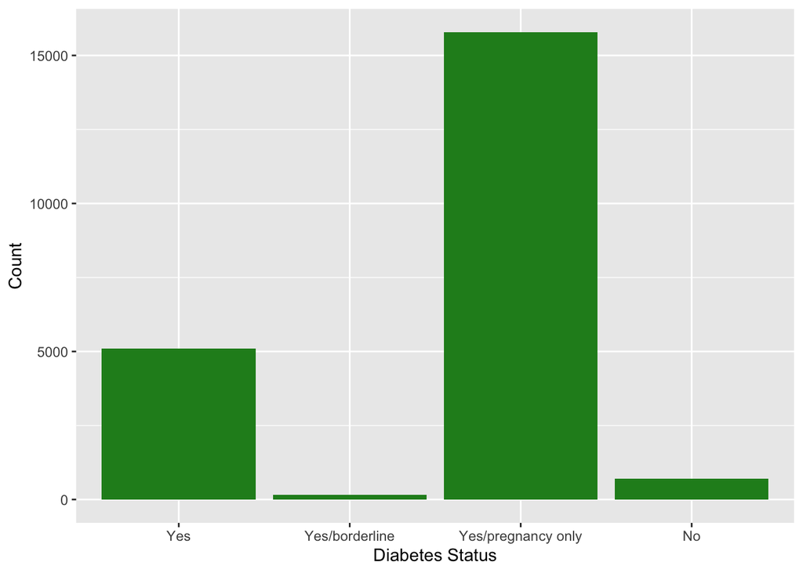

```r
ggplot(Heart_clean, aes(x = Diabetes_Status)) +
  geom_bar(fill = "forestgreen") +
  labs(x = "Diabetes Status", y = "Count")
```

*Most samples have some form of diabetes, especially pregnancy-related.*

## Smoking Status Distribution

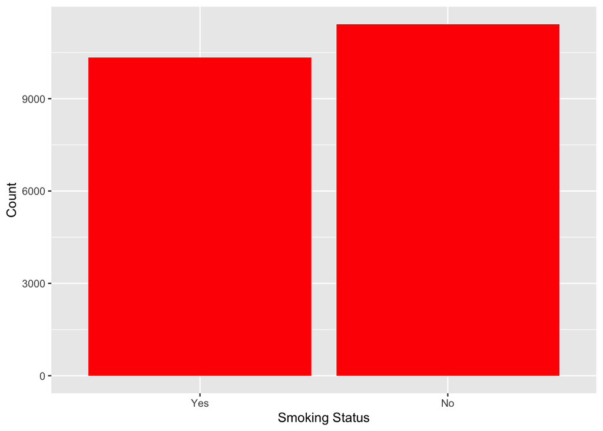

```r
ggplot(Heart_clean, aes(x = Smoking_Status)) +
  geom_bar(fill = "red") +
  labs(x = "Smoking Status", y = "Count")
```

*Non-smokers slightly outnumber smokers.*

## General Health Status Distribution

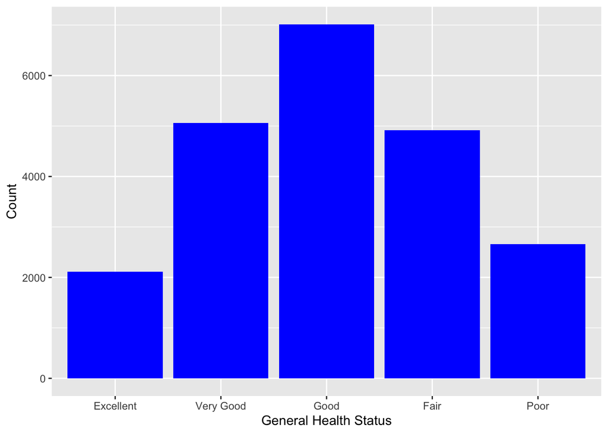

```r
ggplot(Heart_clean, aes(x = General_Health_Status)) +
  geom_bar(fill = "blue") +
  labs(x = "General Health Status", y = "Count")
```

## Exercise in Past 30 Days

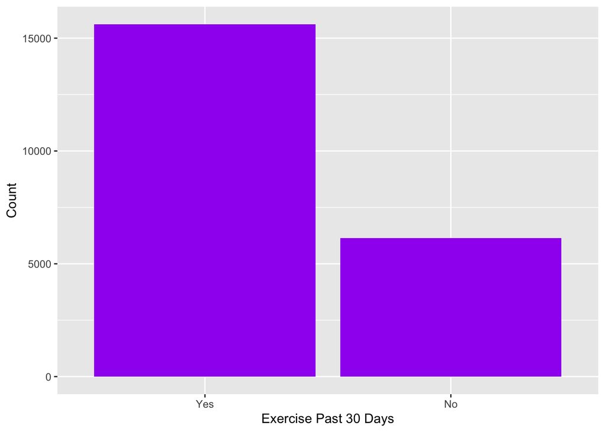

```r
ggplot(Heart_clean, aes(x = Exercise_Past_30_Days)) +
  geom_bar(fill = "purple") +
  labs(x = "Exercise Past 30 Days", y = "Count")
```

*Most samples exercised in the past 30 days.*

## BMI Category Distribution

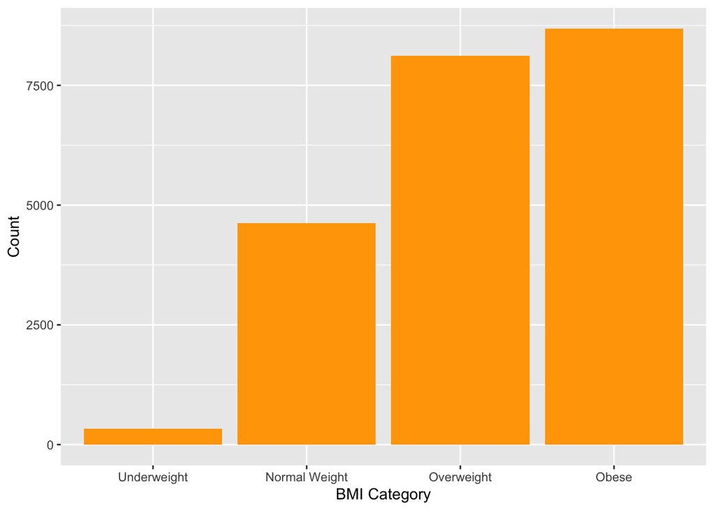

```r
ggplot(Heart_clean, aes(x = BMI_Category_Alt)) +
  geom_bar(fill = "orange") +
  labs(x = "BMI Category", y = "Count")
```

## BMI Value Distribution

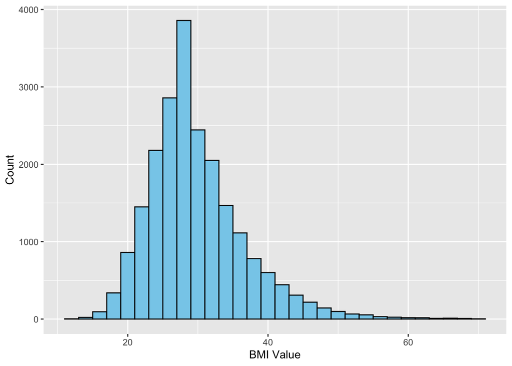

```r
ggplot(na.omit(Heart_clean), aes(x = BMI_Value)) +
  geom_histogram(binwidth = 2, fill = "skyblue", color = "black") +
  labs(x = "BMI Value", y = "Count")
```

*BMI is right-skewed, concentrated in the 20–40 range.*

## Sex Distribution

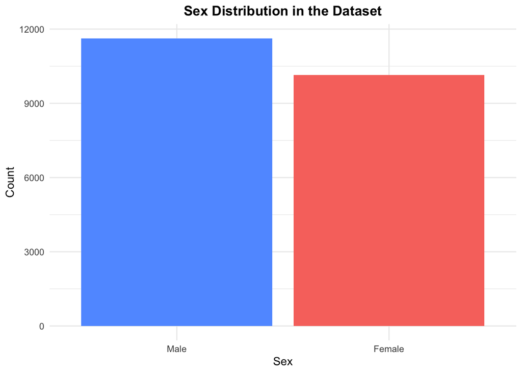

```r
# Bar plot for overall sex distribution in the dataset
ggplot(Heart_clean, aes(x = Sex, fill = Sex)) +
  geom_bar(show.legend = FALSE) +
  labs(
    title = "Sex Distribution in the Dataset",
    x = "Sex",
    y = "Count"
  ) +
  scale_fill_manual(values = c("Male" = "#619CFF", "Female" = "#F8766D")) +
  theme_minimal() +
  theme(plot.title = element_text(hjust = 0.5, face = "bold"))
```

```r
# Print counts and proportions
sex_table <- table(Heart_clean$Sex)
cat("\n=== Sex Distribution (Counts) ===\n")
```

```
##
## === Sex Distribution (Counts) ===
```

```r
print(sex_table)
```

```
##
##   Male Female
##  11624  10142
```

```r
cat("\n=== Sex Distribution (Percentages) ===\n")
```

```
##
## === Sex Distribution (Percentages) ===
```

```r
sex_prop <- prop.table(sex_table) * 100
print(round(sex_prop, 2))
```

```
##
##   Male Female
##   53.4   46.6
```

*The plot and table show the overall male/female distribution in the cleaned dataset. Percentages reflect the study population after cleaning and balancing.*

## Age Distribution

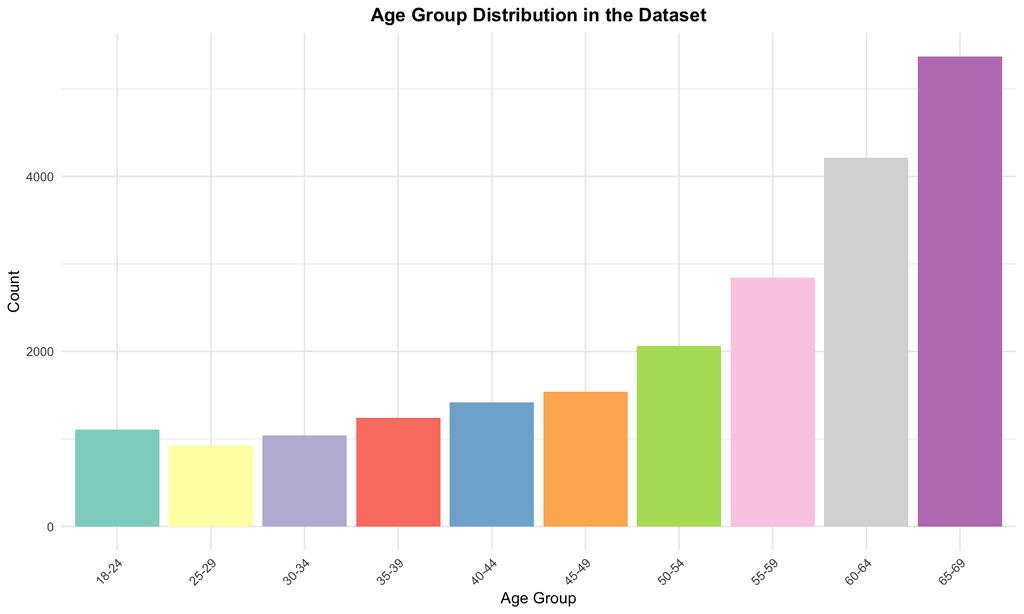

```r
# Bar plot for overall age group distribution in the dataset
ggplot(Heart_clean, aes(x = Age, fill = Age)) +
  geom_bar(show.legend = FALSE) +
  labs(
    title = "Age Group Distribution in the Dataset",
    x = "Age Group",
    y = "Count"
  ) +
  scale_fill_brewer(palette = "Set3") +
  theme_minimal() +
  theme(
    plot.title = element_text(hjust = 0.5, face = "bold"),
    axis.text.x = element_text(angle = 45, hjust = 1)
  )
```

```r
# Print counts and proportions
age_table <- table(Heart_clean$Age)
cat("\n=== Age Group Distribution (Percentages) ===\n")
```

```
##
## === Age Group Distribution (Percentages) ===
```

```r
age_prop <- prop.table(age_table) * 100
print(round(age_prop, 2))
```

```
##
## 18-24 25-29 30-34 35-39 40-44 45-49 50-54 55-59 60-64 65-69
##  5.09  4.25  4.77  5.71  6.52  7.07  9.47 13.08 19.37 24.68
```

*The plot and table show the age group distribution in the cleaned dataset. Older age groups are more represented, which may relate to higher CHD risk.*

# Exploratory Data Analysis

## Q1: Is there a significant difference in BMI between people with and without coronary heart disease?

**Rationale:**

- We want to compare the mean BMI between two independent groups (CHD: Yes vs No). The t-test is appropriate for comparing means of a continuous variable between two groups.

**Hypothesis:**

- Null hypothesis (H0): The mean BMI is the same for people with and without coronary heart disease.
- Alternative hypothesis (H1): The mean BMI differs between people with and without coronary heart disease.

**Statistical Test:** T-test (comparing means of two groups)

```r
aggregate(BMI_Value ~ Coronary_Heart_Disease, data = Heart_clean,
          FUN = function(x) c(mean = mean(x, na.rm = TRUE), sd = sd(x, na.rm = TRUE), count = length(x[!is.na(x)])))
```

```
##   Coronary_Heart_Disease BMI_Value.mean BMI_Value.sd BMI_Value.count
## 1                    Yes          30.63         7.11        10883.00
## 2                     No          28.83         6.49        10883.00
```

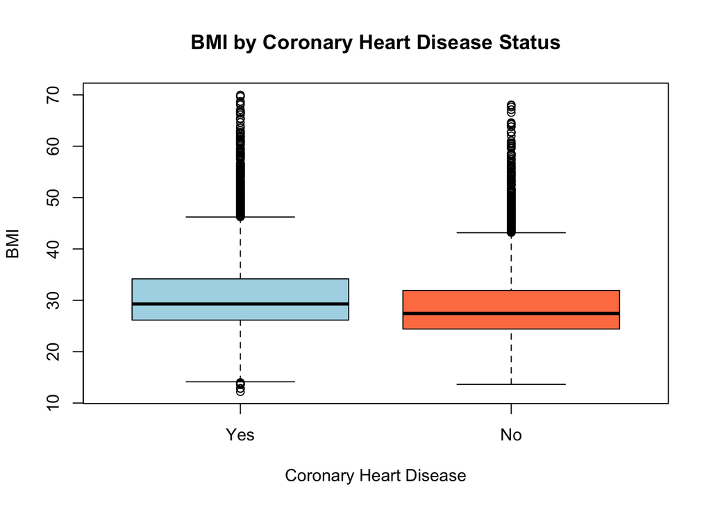

```r
boxplot(BMI_Value ~ Coronary_Heart_Disease, data = Heart_clean,
        main = "BMI by Coronary Heart Disease Status",
        xlab = "Coronary Heart Disease", ylab = "BMI",
        col = c("lightblue", "coral"))
```

```r
t_test_bmi <- t.test(BMI_Value ~ Coronary_Heart_Disease, data = Heart_clean, conf.level = 0.95)
print(t_test_bmi)
```

```
##
##  Welch Two Sample t-test
##
## data:  BMI_Value by Coronary_Heart_Disease
## t = 19, df = 21582, p-value <2e-16
## alternative hypothesis: true difference in means between group Yes and group No is not equal to 0
## 95 percent confidence interval:
##  1.61 1.98
## sample estimates:
## mean in group Yes  mean in group No
##              30.6              28.8
```

```r
if(t_test_bmi$p.value < 0.05) {
  cat("Result: There is a significant difference in BMI between groups (p < 0.05)")
} else {
  cat("Result: There is no significant difference in BMI between groups (p >= 0.05)")
}
```

```
## Result: There is a significant difference in BMI between groups (p < 0.05)
```

*The t-test shows a strong difference in BMI between people with and without CHD (p < 2e-16). Individuals with CHD tend to have higher BMI on average.*

## Q2: Is smoking status associated with coronary heart disease?

**Rationale:**

- We are testing the association between two categorical variables (smoking status and CHD). The chi-square test of independence is suitable for this purpose.

**Hypothesis:**

- Null hypothesis (H0): Smoking status and coronary heart disease are independent (no association).
- Alternative hypothesis (H1): Smoking status and coronary heart disease are associated.

**Statistical Test:** Chi-square test (testing association between two categorical variables)

```r
smoking_table <- table(Heart_clean$Smoking_Status, Heart_clean$Coronary_Heart_Disease)
print(smoking_table)
```

```
##
##        Yes   No
##   Yes 6308 4037
##   No  4575 6846
```

```r
prop_table <- prop.table(smoking_table, margin = 1) * 100
print(round(prop_table, 1))
```

```
##
##        Yes   No
##   Yes 61.0 39.0
##   No  40.1 59.9
```

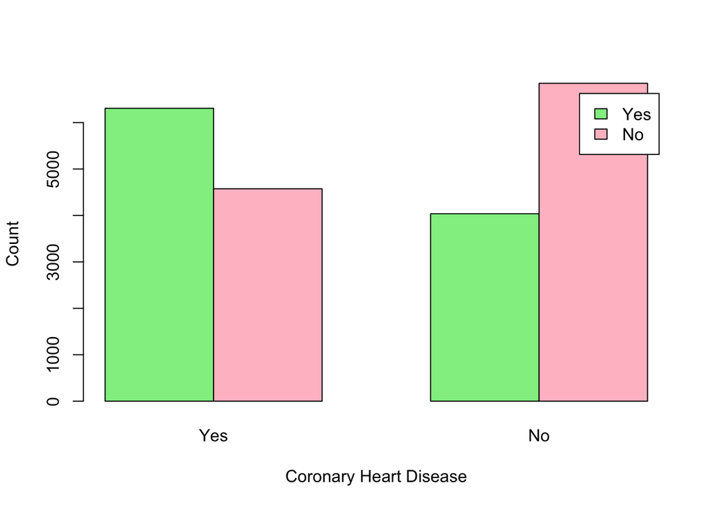

```r
barplot(smoking_table, beside = TRUE,
        xlab = "Coronary Heart Disease", ylab = "Count",
        col = c("lightgreen", "pink"),
        legend = TRUE)
```

```r
chi_test_smoking <- chisq.test(smoking_table)
print(chi_test_smoking)
```

```
##
##  Pearson's Chi-squared test with Yates' continuity correction
##
## data:  smoking_table
## X-squared = 949, df = 1, p-value <2e-16
```

```r
if(chi_test_smoking$p.value < 0.05) {
  cat("Result: There is a significant association between smoking and coronary heart disease (p < 0.05)")
} else {
  cat("Result: There is no significant association between smoking and coronary heart disease (p >= 0.05)")
}
```

```
## Result: There is a significant association between smoking and coronary heart disease (p < 0.05)
```

*The chi-squared test shows a strong relationship between smoking and CHD (p < 2e-16). Smokers are more likely to have CHD than non-smokers.*

## Q3: Is diabetes status associated with coronary heart disease?

**Rationale:**

- We are testing the association between two categorical variables (diabetes status and CHD). The chi-square test of independence is suitable.

**Hypothesis:**

- Null hypothesis (H0): Diabetes status and coronary heart disease are independent (no association).
- Alternative hypothesis (H1): Diabetes status and coronary heart disease are associated (not independent).

**Statistical Test:** Chi-square test (testing association between two categorical variables)

```r
diabetes_table <- table(Heart_clean$Diabetes_Status, Heart_clean$Coronary_Heart_Disease)
print(diabetes_table)
```

```
##
##                       Yes   No
##   Yes                3939 1164
##   Yes/borderline       68   93
##   Yes/pregnancy only 6437 9352
##   No                  439  274
```

```r
prop_table_diabetes <- prop.table(diabetes_table, margin = 1) * 100
print(round(prop_table_diabetes, 1))
```

```
##
##                       Yes   No
##   Yes                77.2 22.8
##   Yes/borderline     42.2 57.8
##   Yes/pregnancy only 40.8 59.2
##   No                 61.6 38.4
```

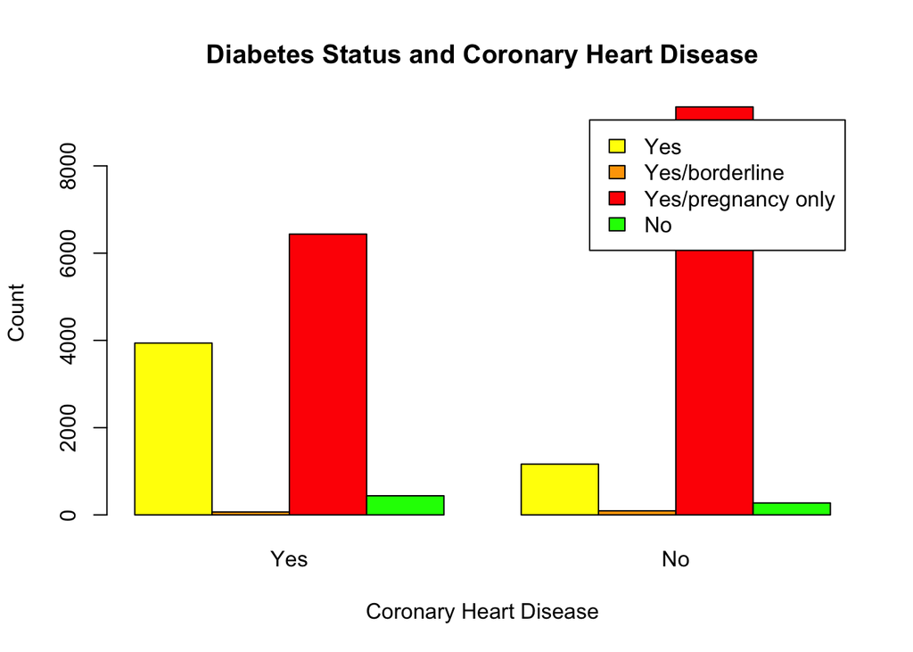

```r
barplot(diabetes_table, beside = TRUE,
        main = "Diabetes Status and Coronary Heart Disease",
        xlab = "Coronary Heart Disease", ylab = "Count",
        col = c("yellow", "orange", "red", "green"),
        legend = TRUE)
```

```r
chi_test_diabetes <- chisq.test(diabetes_table)
print(chi_test_diabetes)
```

```
##
##  Pearson's Chi-squared test
##
## data:  diabetes_table
## X-squared = 2089, df = 3, p-value <2e-16
```

```r
if(chi_test_diabetes$p.value < 0.05) {
  cat("Result: There is a significant association between diabetes and coronary heart disease (p < 0.05)")
} else {
  cat("Result: There is no significant association between diabetes and coronary heart disease (p >= 0.05)")
}
```

```
## Result: There is a significant association between diabetes and coronary heart disease (p < 0.05)
```

*The chi-squared test shows a strong relationship between diabetes and CHD (p < 2e-16). People with diabetes have a much higher chance of CHD.*

## Q4: Is exercise participation associated with coronary heart disease?

**Rationale:**

- We are testing the association between two categorical variables (exercise participation and CHD). The chi-square test of independence is suitable.

**Hypothesis:**

- Null hypothesis (H0): Exercise participation and coronary heart disease are independent (no association).
- Alternative hypothesis (H1): Exercise participation and coronary heart disease are associated (not independent).

**Statistical Test:** Chi-square test (testing association between two categorical variables)

```r
exercise_chd_table <- table(Heart_clean$Exercise_Past_30_Days, Heart_clean$Coronary_Heart_Disease)
print(exercise_chd_table)
```

```
##
##        Yes   No
##   Yes 6978 8642
##   No  3905 2241
```

```r
prop_exercise_chd <- prop.table(exercise_chd_table, margin = 1) * 100
print(round(prop_exercise_chd, 1))
```

```
##
##        Yes   No
##   Yes 44.7 55.3
##   No  63.5 36.5
```

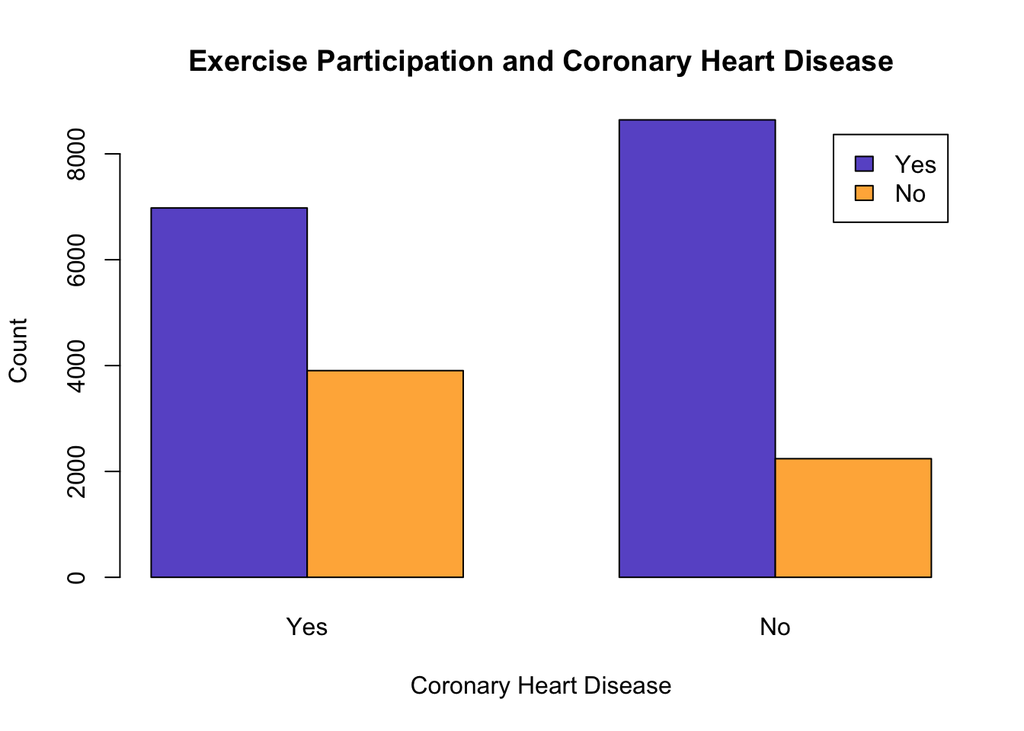

```r
barplot(exercise_chd_table, beside = TRUE,
        main = "Exercise Participation and Coronary Heart Disease",
        xlab = "Coronary Heart Disease", ylab = "Count",
        col = c("#6a5acd", "#ffb347"),
        legend = TRUE)
```

```r
chi_test_exercise <- chisq.test(exercise_chd_table)
print(chi_test_exercise)
```

```
##
##  Pearson's Chi-squared test with Yates' continuity correction
##
## data:  exercise_chd_table
## X-squared = 627, df = 1, p-value <2e-16
```

```r
if(chi_test_exercise$p.value < 0.05) {
  cat("Result: There is a significant association between exercise participation and coronary heart disease (p < 0.05)")
} else {
  cat("Result: There is no significant association between exercise participation and coronary heart disease (p >= 0.05)")
}
```

```
## Result: There is a significant association between exercise participation and coronary heart disease (p < 0.05)
```

*The chi-squared test shows exercise participation is associated with CHD. People who exercise may have a different CHD risk than those who do not.*

## Q5: Is general health status associated with coronary heart disease?

**Rationale:**

- We are testing the association between two categorical variables (general health status and CHD). The chi-square test of independence is suitable for this purpose.

**Hypothesis:**

- Null hypothesis (H0): General health status and coronary heart disease are independent (no association).
- Alternative hypothesis (H1): General health status and coronary heart disease are associated.

**Statistical Test:** Chi-square test (testing association between two categorical variables)

```r
gh_chd_table <- table(Heart_clean$General_Health_Status, Heart_clean$Coronary_Heart_Disease)
print(gh_chd_table)
```

```
##
##              Yes   No
##   Excellent  347 1768
##   Very Good 1483 3579
##   Good      3404 3611
##   Fair      3445 1470
##   Poor      2204  455
```

```r
prop_gh_chd <- prop.table(gh_chd_table, margin = 1) * 100
print(round(prop_gh_chd, 1))
```

```
##
##              Yes   No
##   Excellent 16.4 83.6
##   Very Good 29.3 70.7
##   Good      48.5 51.5
##   Fair      70.1 29.9
##   Poor      82.9 17.1
```

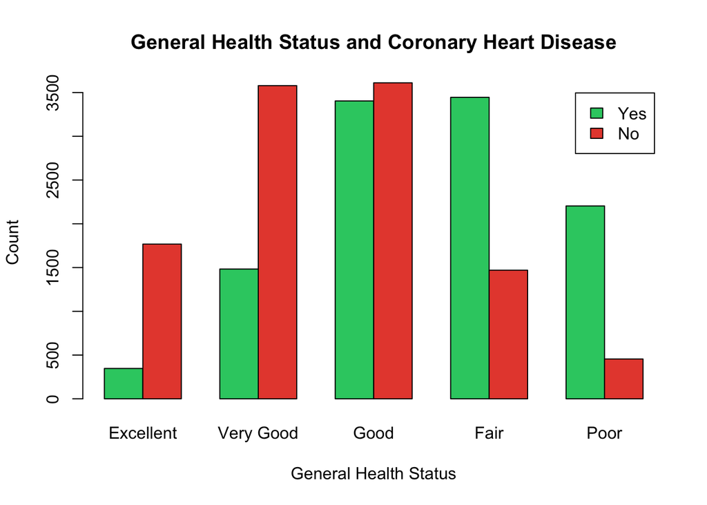

```r
barplot(t(gh_chd_table), beside = TRUE,
        main = "General Health Status and Coronary Heart Disease",
        xlab = "General Health Status", ylab = "Count",
        col = c("#2ecc71", "#e74c3c"),
        legend = colnames(gh_chd_table))
```

```r
chi_test_gh <- chisq.test(gh_chd_table)
print(chi_test_gh)
```

```
##
##  Pearson's Chi-squared test
##
## data:  gh_chd_table
## X-squared = 3773, df = 4, p-value <2e-16
```

```r
if(chi_test_gh$p.value < 0.05) {
  cat("Result: There is a significant association between general health status and coronary heart disease (p < 0.05)")
} else {
  cat("Result: There is no significant association between general health status and coronary heart disease (p >= 0.05)")
}
```

```
## Result: There is a significant association between general health status and coronary heart disease (p < 0.05)
```

*The chi-squared test shows general health status is associated with CHD. People reporting poorer health have a higher CHD risk.*

## Q6: Is age group associated with coronary heart disease?

**Rationale:**

- We are testing the association between two categorical variables (age group and CHD). The chi-square test of independence is suitable for this purpose.

**Hypothesis:**

- Null hypothesis (H0): Age group and coronary heart disease are independent (no association).
- Alternative hypothesis (H1): Age group and coronary heart disease are associated.

**Statistical Test:** Chi-square test (testing association between two categorical variables)

```r
age_chd_table <- table(Heart_clean$Age, Heart_clean$Coronary_Heart_Disease)
print(age_chd_table)
```

```
##
##          Yes   No
##   18-24   88 1019
##   25-29   93  832
##   30-34  149  890
##   35-39  214 1028
##   40-44  363 1057
##   45-49  568  971
##   50-54 1047 1014
##   55-59 1683 1163
##   60-64 2822 1394
##   65-69 3856 1515
```

```r
prop_age_chd <- prop.table(age_chd_table, margin = 1) * 100
print(round(prop_age_chd, 1))
```

```
##
##          Yes   No
##   18-24  7.9 92.1
##   25-29 10.1 89.9
##   30-34 14.3 85.7
##   35-39 17.2 82.8
##   40-44 25.6 74.4
##   45-49 36.9 63.1
##   50-54 50.8 49.2
##   55-59 59.1 40.9
##   60-64 66.9 33.1
##   65-69 71.8 28.2
```

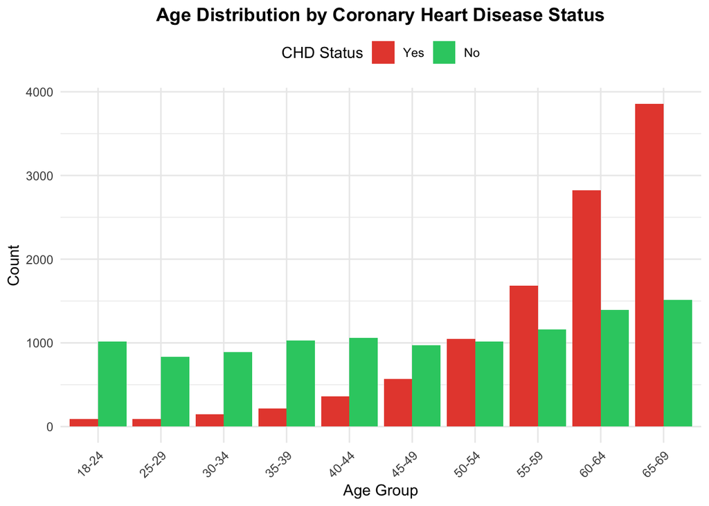

```r
# barplot(t(age_chd_table), beside = TRUE,
#         main = "Age Group and Coronary Heart Disease",
#         xlab = "Age Group", ylab = "Count",
#         col = c("#2ecc71", "#e74c3c"),
#         legend = colnames(age_chd_table))

# Create a grouped bar plot for Age vs CHD
ggplot(Heart_clean, aes(x = Age, fill = Coronary_Heart_Disease)) +
  geom_bar(position = "dodge") +
  labs(
    title = "Age Distribution by Coronary Heart Disease Status",
    x = "Age Group",
    y = "Count",
    fill = "CHD Status"
  ) +
  scale_fill_manual(values = c("Yes" = "#e74c3c", "No" = "#2ecc71")) +
  theme_minimal() +
  theme(
    plot.title = element_text(hjust = 0.5, face = "bold"),
    axis.text.x = element_text(angle = 45, hjust = 1),
    legend.position = "top"
  )
```

```r
chi_test_age <- chisq.test(age_chd_table)
print(chi_test_age)
```

```
##
##  Pearson's Chi-squared test
##
## data:  age_chd_table
## X-squared = 4480, df = 9, p-value <2e-16
```

```r
if(chi_test_age$p.value < 0.05) {
  cat("Result: There is a significant association between age group and coronary heart disease (p < 0.05)")
} else {
  cat("Result: There is no significant association between age group and coronary heart disease (p >= 0.05)")
}
```

```
## Result: There is a significant association between age group and coronary heart disease (p < 0.05)
```

*Older age groups (50-69) have much higher CHD rates than younger groups. The chi-squared test confirms age group is associated with CHD.*

## Q7: Is sex associated with coronary heart disease?

**Rationale:**

- We are testing the association between two categorical variables (sex and CHD). The chi-square test of independence is suitable.

**Hypothesis:**

- Null hypothesis (H0): Sex and coronary heart disease are independent (no association).
- Alternative hypothesis (H1): Sex and coronary heart disease are associated (not independent).

**Statistical Test:** Chi-square test (testing association between two categorical variables)

```r
sex_chd_table <- table(Heart_clean$Sex, Heart_clean$Coronary_Heart_Disease)
print(sex_chd_table)
```

```
##
##           Yes   No
##   Male   6255 5369
##   Female 4628 5514
```

```r
prop_sex_chd <- prop.table(sex_chd_table, margin = 1) * 100
print(round(prop_sex_chd, 1))
```

```
##
##           Yes   No
##   Male   53.8 46.2
##   Female 45.6 54.4
```

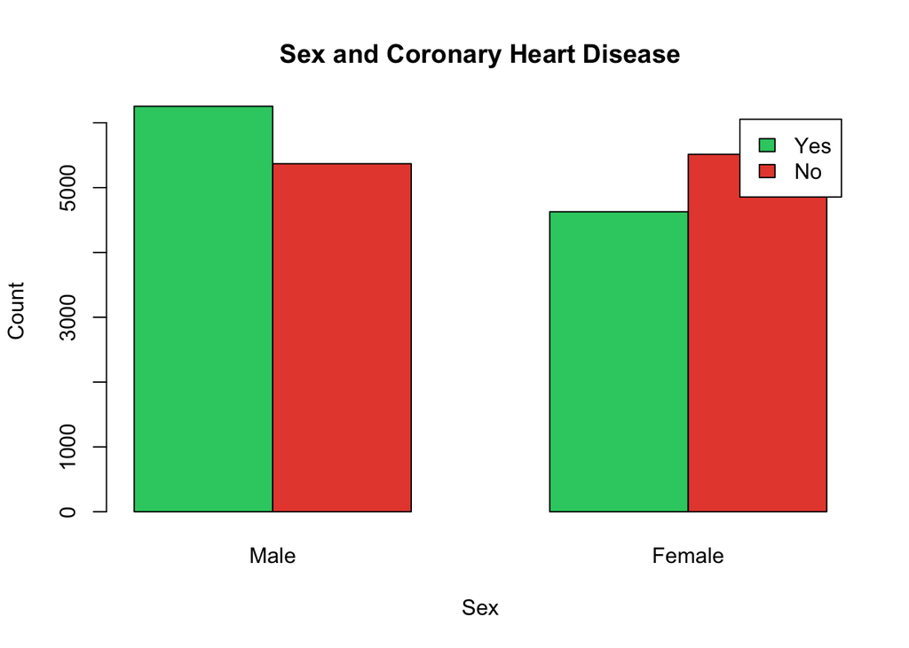

```r
barplot(t(sex_chd_table), beside = TRUE,
        main = "Sex and Coronary Heart Disease",
        xlab = "Sex", ylab = "Count",
        col = c("#2ecc71", "#e74c3c"),
        legend = colnames(sex_chd_table))
```

```r
chi_test_sex <- chisq.test(sex_chd_table)
print(chi_test_sex)
```

```
##
##  Pearson's Chi-squared test with Yates' continuity correction
##
## data:  sex_chd_table
## X-squared = 145, df = 1, p-value <2e-16
```

```r
if(chi_test_sex$p.value < 0.05) {
  cat("Result: There is a significant association between sex and coronary heart disease (p < 0.05)")
} else {
  cat("Result: There is no significant association between sex and coronary heart disease (p >= 0.05)")
}
```

```
## Result: There is a significant association between sex and coronary heart disease (p < 0.05)
```

*The chi-squared test shows sex is associated with CHD (p < 0.05). Males have a higher proportion of CHD than females.*

# Model Building and Training for CHD Prediction

## Final Data Overview and Class Distribution

```r
# Display summary statistics for key variables
summary(Heart_clean[, c("Coronary_Heart_Disease", "Age", "Sex", "Smoking_Status",
                       "Diabetes_Status", "Exercise_Past_30_Days", "General_Health_Status")])
```

```
##  Coronary_Heart_Disease      Age           Sex        Smoking_Status
##  Yes:10883              65-69  :5371   Male  :11624   Yes:10345
##  No :10883              60-64  :4216   Female:10142   No :11421
##                         55-59  :2846
##                         50-54  :2061
##                         45-49  :1539
##                         40-44  :1420
##                         (Other):4313
##            Diabetes_Status  Exercise_Past_30_Days General_Health_Status
##  Yes               : 5103   Yes:15620             Excellent:2115
##  Yes/borderline    :  161   No : 6146             Very Good:5062
##  Yes/pregnancy only:15789                         Good     :7015
##  No                :  713                         Fair     :4915
##                                                   Poor     :2659
##
##
```

```r
# Check class distribution
chd_distribution <- table(Heart_clean$Coronary_Heart_Disease)
print("Coronary Heart Disease Distribution:")
```

```
## [1] "Coronary Heart Disease Distribution:"
```

```r
print(chd_distribution)
```

```
##
##   Yes    No
## 10883 10883
```

```r
cat("Imbalance ratio (No:Yes):", round(chd_distribution["No"]/chd_distribution["Yes"], 1), ":1\n")
```

```
## Imbalance ratio (No:Yes): 1 :1
```

## Data Splitting and Preparation

```r
library(caret)
library(rpart)
library(rpart.plot)

set.seed(123)  # For reproducibility

# Create stratified train/test split (70/30)
train_index <- createDataPartition(Heart_clean$Coronary_Heart_Disease, p = 0.7, list = FALSE)
train_data <- Heart_clean[train_index, ]
test_data <- Heart_clean[-train_index, ]

cat("Training set size:", nrow(train_data), "\n")
```

```
## Training set size: 15238
```

```r
cat("Test set size:", nrow(test_data), "\n")
```

```
## Test set size: 6528
```

```r
# Check class distribution in training data
train_class_dist <- table(train_data$Coronary_Heart_Disease)
print("Training data class distribution:")
```

```
## [1] "Training data class distribution:"
```

```r
print(train_class_dist)
```

```
##
##  Yes   No
## 7619 7619
```

```r
# Print the overall CHD Yes count in training data
cat("Overall CHD Yes count in training data:", train_class_dist["Yes"], "\n")
```

```
## Overall CHD Yes count in training data: 7619
```

## Random Forest Model Training

```r
library(dplyr)
library(caret)
library(ranger)
library(pROC)

# Select the key predictors (justified by statistical tests above)
rf_df <- Heart_clean %>%
  select(Age, Sex, Coronary_Heart_Disease, Smoking_Status, Diabetes_Status,
         Exercise_Past_30_Days, General_Health_Status, BMI_Value) %>%
  na.omit()

# Ensure correct data types
rf_df <- rf_df %>%
  mutate(across(c(Age, Sex, Smoking_Status, Diabetes_Status,
                  Exercise_Past_30_Days, General_Health_Status,
                  Coronary_Heart_Disease), as.factor))

# Split the dataset
set.seed(123)
train_index <- createDataPartition(rf_df$Coronary_Heart_Disease, p = 0.7, list = FALSE)

train_rf <- rf_df[train_index, ]
test_rf  <- rf_df[-train_index, ]

# Train RF with optimized parameters for small dataset
set.seed(123)

rf_orig <- ranger(
  formula = Coronary_Heart_Disease ~ .,
  data = train_rf,
  num.trees = 500,           # Good for small datasets (500-1000 is standard)
  mtry = floor(sqrt(ncol(train_rf) - 1)),  # Standard for classification (√p)
  importance = "permutation",  # Good choice for interpretability
  min.node.size = 5,          # Reduced from 10 to allow finer splits with small dataset
  probability = TRUE,
  sample.fraction = 0.7,      # Use 70% of training data per tree (helps with small datasets)
  replace = TRUE              # Bootstrap sampling (default, but explicit for clarity)
)

rf_orig
```

```
## Ranger result
##
## Call:
##  ranger(formula = Coronary_Heart_Disease ~ ., data = train_rf,      num.trees = 500, mtry = floor(sqrt(ncol(train_rf) - 1)),      importance = "permutation", min.node.size = 5, probability = TRUE,      sample.fraction = 0.7, replace = TRUE)
##
## Type:                             Probability estimation
## Number of trees:                  500
## Sample size:                      15238
## Number of independent variables:  7
## Mtry:                             2
## Target node size:                 5
## Variable importance mode:         permutation
## Splitrule:                        gini
## OOB prediction error (Brier s.):  0.167
```

**Random Forest Model Summary**

*The random forest model was trained using 500 trees, with 2 variables tried at each split (mtry), and a minimum node size of 5 to allow for finer splits given the small dataset size. The model uses permutation importance for interpretability and samples 70% of the training data for each tree to enhance robustness.*

*The out-of-bag Brier score is 0.167. This is the mean squared error of the predicted probabilities vs. actual outcomes (lower is better; 0 is perfect, 0.25 is random guessing for balanced classes).*

## Random Forest Model evaluation

```r
# Predict probabilities (extract "Yes" column)
pred_prob_orig <- predict(rf_orig, data = test_rf)$predictions[, "Yes"]

# ROC + optimal cutoff (Youden)
roc_obj_rf <- roc(test_rf$Coronary_Heart_Disease, pred_prob_orig)
best <- coords(roc_obj_rf, "best", best.method = "youden", ret = c("threshold","sensitivity","specificity"))
print(best)
```

```
##   threshold sensitivity specificity
## 1     0.459       0.703       0.835
## 2     0.458       0.702       0.835
```

```r
optimal_cutoff_rf <- best$threshold[1]

# Classify with optimal cutoff
pred_class_rf_opt <- factor(ifelse(pred_prob_orig >= optimal_cutoff_rf, "Yes", "No"),
                            levels = c("No","Yes"))

# Confusion matrix + metrics
conf_opt <- confusionMatrix(pred_class_rf_opt, test_rf$Coronary_Heart_Disease)
print(conf_opt)
```

```
## Confusion Matrix and Statistics
##
##           Reference
## Prediction  Yes   No
##        Yes 2725  970
##        No   539 2294
##
##                Accuracy : 0.769
##                  95% CI : (0.758, 0.779)
##     No Information Rate : 0.5
##     P-Value [Acc > NIR] : <2e-16
##
##                   Kappa : 0.538
##
##  Mcnemar's Test P-Value : <2e-16
##
##             Sensitivity : 0.835
##             Specificity : 0.703
##          Pos Pred Value : 0.737
##          Neg Pred Value : 0.810
##              Prevalence : 0.500
##          Detection Rate : 0.417
##    Detection Prevalence : 0.566
##       Balanced Accuracy : 0.769
##
##        'Positive' Class : Yes
##
```

```r
TP <- conf_opt$table[2,2]
TN <- conf_opt$table[1,1]
FP <- conf_opt$table[1,2]
FN <- conf_opt$table[2,1]

# Calculate additional metrics
metrics_df <- data.frame(
  Metric = c("Accuracy", "Precision", "Recall", "F1-score", "Specificity"),
  Value  = round(c(
    (TP + TN) / (TP + TN + FP + FN),
    ifelse((TP + FP) == 0, NA, TP / (TP + FP)),
    ifelse((TP + FN) == 0, NA, TP / (TP + FN)),
    ifelse((TP + FP) == 0 | (TP + FN) == 0, NA, 2 * ( (TP / (TP + FP)) * (TP / (TP + FN)) / ((TP / (TP + FP)) + (TP / (TP + FN))) )),
    ifelse((TN + FP) == 0, NA, TN / (TN + FP))
  ), 4)
)
print(metrics_df)
```

```
##        Metric Value
## 1    Accuracy 0.769
## 2   Precision 0.703
## 3      Recall 0.810
## 4    F1-score 0.752
## 5 Specificity 0.738
```

```r
# Print AUC for reference
cat("AUC:", round(as.numeric(auc(roc_obj_rf)), 4), "\n")
```

```
## AUC: 0.834
```

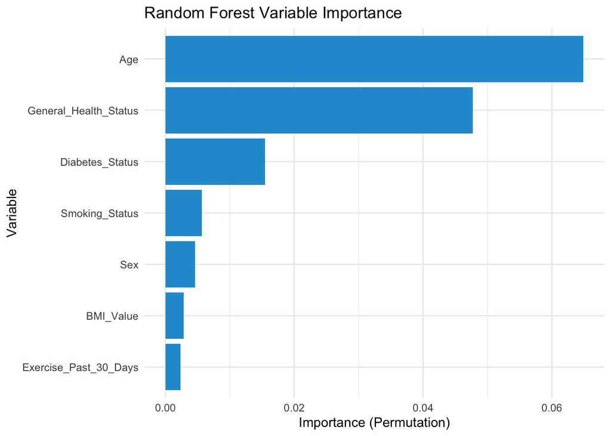

```r
# --- Variable Importance Plot ---
# Extract and prepare importance
var_imp <- as.data.frame(rf_orig$variable.importance)
var_imp$Variable <- rownames(var_imp)
colnames(var_imp)[1] <- "Importance"
var_imp <- var_imp[order(var_imp$Importance, decreasing = TRUE), ]

# Plot variable importance
ggplot(var_imp, aes(x = reorder(Variable, Importance), y = Importance)) +
  geom_col(fill = "#249bd3") +
  coord_flip() +
  labs(title = "Random Forest Variable Importance",
       x = "Variable", y = "Importance (Permutation)") +
  theme_minimal()
```

## Categorical Tree Model Training

```r
library(rpart)
library(rpart.plot)
library(caret)

# Use the same train/test split as Random Forest (already created above)

# Train Decision Tree with complexity parameter tuning
set.seed(123)

# Build initial tree
tree_model <- rpart(
  formula = Coronary_Heart_Disease ~ Age + Sex + Smoking_Status + Diabetes_Status +
                                      Exercise_Past_30_Days + General_Health_Status + BMI_Value,
  data = train_rf,
  method = "class",
  control = rpart.control(
    cp = 0.001,        # Complexity parameter (lower = more splits)
    minsplit = 20,     # Minimum observations to attempt split
    minbucket = 10,    # Minimum observations in terminal node
    maxdepth = 10      # Maximum tree depth
  )
)

# Print tree summary
# cat("=== Decision Tree Model Summary ===\n")
# print(tree_model)

# Display complexity parameter table
cat("\n=== Complexity Parameter Table ===\n")
```

```
##
## === Complexity Parameter Table ===
```

```r
printcp(tree_model)
```

```
##
## Classification tree:
## rpart(formula = Coronary_Heart_Disease ~ Age + Sex + Smoking_Status +
##     Diabetes_Status + Exercise_Past_30_Days + General_Health_Status +
##     BMI_Value, data = train_rf, method = "class", control = rpart.control(cp = 0.001,
##     minsplit = 20, minbucket = 10, maxdepth = 10))
##
## Variables actually used in tree construction:
## [1] Age                   BMI_Value             Diabetes_Status
## [4] General_Health_Status Sex                   Smoking_Status
##
## Root node error: 7619/15238 = 0.5
##
## n= 15238
##
##       CP nsplit rel error xerror  xstd
## 1  0.396      0       1.0    1.0 0.008
## 2  0.078      1       0.6    0.6 0.007
## 3  0.006      2       0.5    0.5 0.007
## 4  0.006      4       0.5    0.5 0.007
## 5  0.006      6       0.5    0.5 0.007
## 6  0.004      7       0.5    0.5 0.007
## 7  0.003      9       0.5    0.5 0.007
## 8  0.002     10       0.5    0.5 0.007
## 9  0.002     17       0.5    0.5 0.007
## 10 0.001     18       0.5    0.5 0.007
## 11 0.001     19       0.5    0.5 0.007
## 12 0.001     20       0.5    0.5 0.007
```

```r
# Find optimal CP (minimum xerror)
optimal_cp <- tree_model$cptable[which.min(tree_model$cptable[,"xerror"]),"CP"]
cat(sprintf("\nOptimal Complexity Parameter (CP): %.5f\n", optimal_cp))
```

```
##
## Optimal Complexity Parameter (CP): 0.00105
```

*The optimal Complexity Parameter of 0.00105 is a cost-complexity pruning metric selected via 10-fold cross-validation that balances tree complexity with accuracy, preventing overfitting to training noise while improving generalization to new patients and enhancing interpretability with clinical decision rules doctors can easily follow, this value represents the sweet spot between underfitting (CP too high 0.1) and overfitting (CP too low 0.0001), ensuring that when the tree is pruned, only the most meaningful and predictive splits are retained, transforming a complex full tree into a robust, interpretable model suitable for real-world CHD risk assessment.*

```r
# Prune tree to optimal CP
tree_pruned <- prune(tree_model, cp = optimal_cp)

# cat("\n=== Pruned Decision Tree Summary ===\n")
# print(tree_pruned)
```

## Decision Tree Visualization

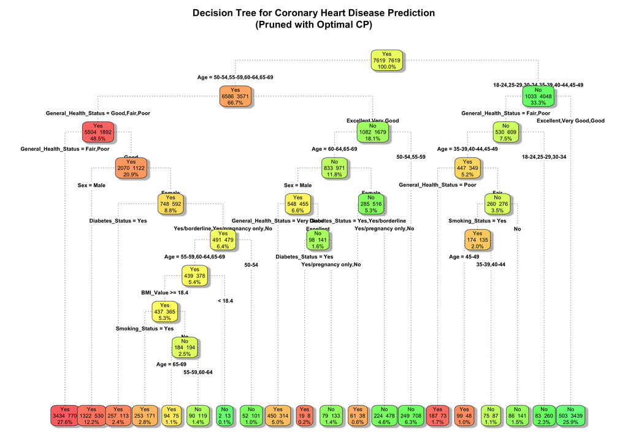

```r
# Visualize the pruned decision tree
rpart.plot(
  tree_pruned,
  type = 4,              # Display all node labels
  extra = 101,           # Display number of observations and percentage
  fallen.leaves = TRUE,  # Put leaves at bottom
  branch.lty = 3,        # Dotted branch lines
  shadow.col = "gray",   # Add shadow
  box.palette = "RdYlGn", # Red-Yellow-Green color scheme
  main = "Decision Tree for Coronary Heart Disease Prediction\n(Pruned with Optimal CP)",
  cex.main = 1.3,
  digits = 3,
  tweak = 1.2            # Scale text size
)
```

## Decision Tree Performance Evaluation

```r
# Predict on test set
tree_pred_class <- predict(tree_pruned, newdata = test_rf, type = "class")
tree_pred_prob <- predict(tree_pruned, newdata = test_rf, type = "prob")[, "Yes"]

# Confusion Matrix
conf_tree <- confusionMatrix(tree_pred_class, test_rf$Coronary_Heart_Disease)

# Display confusion matrix (compact output)
print(conf_tree)
```

```
## Confusion Matrix and Statistics
##
##           Reference
## Prediction  Yes   No
##        Yes 2607  884
##        No   657 2380
##
##                Accuracy : 0.764
##                  95% CI : (0.753, 0.774)
##     No Information Rate : 0.5
##     P-Value [Acc > NIR] : < 2e-16
##
##                   Kappa : 0.528
##
##  Mcnemar's Test P-Value : 8.55e-09
##
##             Sensitivity : 0.799
##             Specificity : 0.729
##          Pos Pred Value : 0.747
##          Neg Pred Value : 0.784
##              Prevalence : 0.500
##          Detection Rate : 0.399
##    Detection Prevalence : 0.535
##       Balanced Accuracy : 0.764
##
##        'Positive' Class : Yes
##
```

```r
# Extract metrics
TP_tree <- conf_tree$table[2,2]
TN_tree <- conf_tree$table[1,1]
FP_tree <- conf_tree$table[1,2]
FN_tree <- conf_tree$table[2,1]

# Calculate comprehensive metrics
metrics_tree <- data.frame(
  Metric = c("Accuracy", "Precision (PPV)", "Recall (Sensitivity)", "Specificity", "F1-Score", "AUC"),
  Value  = round(c(
    (TP_tree + TN_tree) / (TP_tree + TN_tree + FP_tree + FN_tree),
    ifelse((TP_tree + FP_tree) == 0, NA, TP_tree / (TP_tree + FP_tree)),
    ifelse((TP_tree + FN_tree) == 0, NA, TP_tree / (TP_tree + FN_tree)),
    ifelse((TN_tree + FP_tree) == 0, NA, TN_tree / (TN_tree + FP_tree)),
    ifelse((TP_tree + FP_tree) == 0 | (TP_tree + FN_tree) == 0, NA,
           2 * ((TP_tree / (TP_tree + FP_tree)) * (TP_tree / (TP_tree + FN_tree))) /
               ((TP_tree / (TP_tree + FP_tree)) + (TP_tree / (TP_tree + FN_tree)))),
    as.numeric(pROC::auc(pROC::roc(test_rf$Coronary_Heart_Disease, tree_pred_prob)))
  ), 4),
  Percentage = paste0(round(c(
    (TP_tree + TN_tree) / (TP_tree + TN_tree + FP_tree + FN_tree),
    ifelse((TP_tree + FP_tree) == 0, NA, TP_tree / (TP_tree + FP_tree)),
    ifelse((TP_tree + FN_tree) == 0, NA, TP_tree / (TP_tree + FN_tree)),
    ifelse((TN_tree + FP_tree) == 0, NA, TN_tree / (TN_tree + FP_tree)),
    ifelse((TP_tree + FP_tree) == 0 | (TP_tree + FN_tree) == 0, NA,
           2 * ((TP_tree / (TP_tree + FP_tree)) * (TP_tree / (TP_tree + FN_tree))) /
               ((TP_tree / (TP_tree + FP_tree)) + (TP_tree / (TP_tree + FN_tree)))),
    as.numeric(pROC::auc(pROC::roc(test_rf$Coronary_Heart_Disease, tree_pred_prob)))
  ) * 100, 2), "%")
)

# Display metrics table
kable(metrics_tree,
      caption = "Decision Tree Model Performance Metrics",
      align = 'c') %>%
  kable_styling(bootstrap_options = c("striped", "hover"), full_width = FALSE)
```

Decision Tree Model Performance Metrics

| Metric | Value | Percentage |
| --- | --- | --- |
| Accuracy | 0.764 | 76.39% |
| Precision (PPV) | 0.729 | 72.92% |
| Recall (Sensitivity) | 0.784 | 78.37% |
| Specificity | 0.747 | 74.68% |
| F1-Score | 0.755 | 75.54% |
| AUC | 0.817 | 81.7% |

## Variable Importance in Decision Tree

```r
# Extract variable importance from decision tree
tree_importance <- tree_pruned$variable.importance

if(length(tree_importance) > 0) {
  # Convert to data frame
  tree_var_imp <- data.frame(
    Variable = names(tree_importance),
    Importance = as.numeric(tree_importance)
  )
  tree_var_imp <- tree_var_imp[order(tree_var_imp$Importance, decreasing = TRUE), ]

  # Plot variable importance
  ggplot(tree_var_imp, aes(x = reorder(Variable, Importance), y = Importance)) +
    geom_col(fill = "#e74c3c") +
    coord_flip() +
    labs(title = "Decision Tree Variable Importance",
         subtitle = "Based on total decrease in node impurity",
         x = "Variable",
         y = "Importance") +
    theme_minimal() +
    theme(plot.title = element_text(hjust = 0.5, face = "bold"),
          plot.subtitle = element_text(hjust = 0.5))

  # Print importance table
  kable(tree_var_imp,
        caption = "Variables Ranked by Importance in Decision Tree",
        align = 'c',
        row.names = FALSE) %>%
    kable_styling(bootstrap_options = c("striped", "hover"), full_width = FALSE)
} else {
  cat("No variable importance available (tree may be too simple)\n")
}
```

Variables Ranked by Importance in Decision Tree

| Variable | Importance |
| --- | --- |
| Age | 1461.83 |
| General_Health_Status | 866.55 |
| Sex | 70.00 |
| Diabetes_Status | 61.28 |
| BMI_Value | 18.23 |
| Smoking_Status | 14.75 |
| Exercise_Past_30_Days | 9.85 |

## ROC Curve Comparison: Random Forest vs Decision Tree

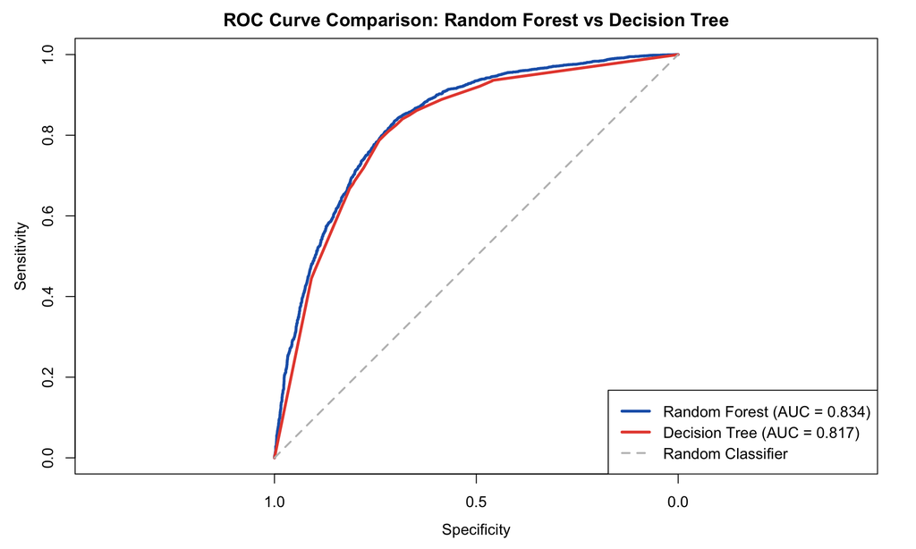

```r
# Create ROC objects for both models
roc_rf <- pROC::roc(test_rf$Coronary_Heart_Disease, pred_prob_orig,
                    direction = "<", levels = c("No", "Yes"))
roc_tree <- pROC::roc(test_rf$Coronary_Heart_Disease, tree_pred_prob,
                      direction = "<", levels = c("No", "Yes"))

# Plot Random Forest ROC curve
plot(roc_rf, col = "#1c61b6", lwd = 3,
     main = "ROC Curve Comparison: Random Forest vs Decision Tree",
     xlab = "Specificity",
     ylab = "Sensitivity",
     legacy.axes = FALSE,  # Medical format: Specificity 1 to 0, Sensitivity 0 to 1
     xlim = c(1, 0),  # X-axis goes from 1 (left) to 0 (right) very few false positives to many false positives
     ylim = c(0, 1), # Y-axis goes from 0 (bottom) to 1 (top) very few true positives to many true positives
     identity = FALSE,
     print.auc = FALSE)

# Add Decision Tree ROC curve
plot(roc_tree, col = "#e74c3c", lwd = 3, add = TRUE)

# Add diagonal reference line (random classifier)
segments(x0 = 1, y0 = 0, x1 = 0, y1 = 1, lty = 2, col = "gray", lwd = 2)

# Add legend with AUC values
legend("bottomright",
       legend = c(paste0("Random Forest (AUC = ", round(pROC::auc(roc_rf), 3), ")"),
                  paste0("Decision Tree (AUC = ", round(pROC::auc(roc_tree), 3), ")"),
                  "Random Classifier"),
       col = c("#1c61b6", "#e74c3c", "gray"),
       lwd = c(3, 3, 2),
       lty = c(1, 1, 2))
```

## Model Comparison: Random Forest vs Decision Tree

```r
# Get AUC for Random Forest (it was printed separately)
rf_auc <- as.numeric(auc(roc_obj_rf))

# Create comparison table with matching metrics
model_comparison <- data.frame(
  Metric = c("Accuracy", "Precision", "Sensitivity", "Specificity", "F1-Score", "AUC"),
  Random_Forest = c(
    metrics_df$Value[1],  # Accuracy
    metrics_df$Value[2],  # Precision
    metrics_df$Value[3],  # Recall/Sensitivity
    metrics_df$Value[5],  # Specificity
    metrics_df$Value[4],  # F1-score
    rf_auc                # AUC
  ),
  Decision_Tree = metrics_tree$Value,
  stringsAsFactors = FALSE
)

# Calculate difference
model_comparison$Difference <- model_comparison$Random_Forest - model_comparison$Decision_Tree

# Add percentage columns
model_comparison$RF_Pct <- paste0(round(model_comparison$Random_Forest * 100, 2), "%")
model_comparison$DT_Pct <- paste0(round(model_comparison$Decision_Tree * 100, 2), "%")
model_comparison$Diff_Pct <- paste0(ifelse(model_comparison$Difference > 0, "+", ""),
                                     round(model_comparison$Difference * 100, 2), "%")

# Display comparison (remove print() for proper HTML rendering)
kable(model_comparison[, c("Metric", "RF_Pct", "DT_Pct", "Diff_Pct")],
      caption = "Model Performance Comparison: Random Forest vs Decision Tree",
      align = 'c',
      col.names = c("Metric", "Random Forest", "Decision Tree", "Difference (RF - DT)"),
      row.names = FALSE) %>%
  kable_styling(bootstrap_options = c("striped", "bordered", "hover"), full_width = FALSE)
```

Model Performance Comparison: Random Forest vs Decision Tree

| Metric | Random Forest | Decision Tree | Difference (RF - DT) |
| --- | --- | --- | --- |
| Accuracy | 76.88% | 76.39% | +0.49% |
| Precision | 70.28% | 72.92% | -2.64% |
| Sensitivity | 80.97% | 78.37% | +2.6% |
| Specificity | 73.75% | 74.68% | -0.93% |
| F1-Score | 75.25% | 75.54% | -0.29% |
| AUC | 83.43% | 81.7% | +1.73% |

# Conclusion

A supervised AI web application has been developed and hosted in GitHub to predict CHD risk using the above decision tree model trained on the BRFSS 2024 dataset. This interactive tool leverages supervised machine learning to estimate individual CHD risk based on user input. Try the CHD risk prediction demo here: https://dhanushgwu1995.github.io/6101-mid-term-project/predict

## Limitations

- Results are based on available data with some missing values
- Cross-sectional data limits causal conclusions

## Practical Implications

These results help identify key CHD risk factors and can guide screening, public health interventions, and patient care to reduce CHD through lifestyle changes.

## References

Tsao, C. W., & Vasan, R. S. (2015). Cohort profile: The Framingham Heart Study (FHS): Overview of milestones in cardiovascular epidemiology. *International Journal of Epidemiology*, *44*(6), 1800–1813. https://doi.org/10.1093/ije/dyv337

Yusuf, S., Hawken, S., Ounpuu, S., Dans, T., Avezum, A., Lanas, F., McQueen, M., Budaj, A., Pais, P., Varigos, J., Liu, L., & INTERHEART Study Investigators. (2004). Effect of potentially modifiable risk factors associated with myocardial infarction in 52 countries (the INTERHEART study): Case-control study. *The Lancet*, *364*(9438), 937–952. https://doi.org/10.1016/S0140-6736(04)17018-9